# DB_California_Housing_Predictions_MLGEO

MZ370G24 - MLGEO  
Author: Ing. Doudou BA  
Professor: Ing. Lukáš Brodský, Ph.D.  
Charles University  
Prague May 2022

```python
#Contents
#1 Introduction
#1.1 Assignment . . . . . . . . . . . . . . . . . . . . . . . . . . . . . . . . . . . . . . . . .
#1.2 Methodology . . . . . . . . . . . . . . . . . . . . . . . . . . . . . . . . . . . . . . . .
#2. Data Understanding
#2.1. Raw data description . . . . . . . . . . . . . . . . . . . . . . . . . . . . . . . . . . . .
#3 Data Preparation
#3.1 Data Preprocessing - cleaning - Transformation . . . . . . . . . . . . . . . . . . . . .
#3.2 Data Exploration . . . . . . . . . . . . . . . . . . . . . . . . . . . . . . . . . . . . . .
#3.3 Visualization . . . . . . . . . . . . . . . . . . . . . . . . . . . . . . . . . . . . . . . .
#4 Modelling
#5 Evaluation
#6 Conclusion
```

## 1. Introduction

```python
import datetime
from tqdm.notebook import tqdm
from sklearn.model_selection import train_test_split
from sklearn.tree import DecisionTreeClassifier
from sklearn.ensemble import AdaBoostClassifier
from sklearn.metrics import roc_auc_score
import pandas as pd
import os
import numpy as np
from sklearn.datasets import make_classification
from sklearn.model_selection import RepeatedStratifiedKFold
from sklearn.model_selection import GridSearchCV
import matplotlib.pyplot as plt
from sklearn.linear_model import LogisticRegression, LinearRegression
from sklearn.model_selection import cross_val_score
import statsmodels.api as sm
import statsmodels.formula.api as smf
pd.set_option("display.precision", 2)
plt.rcParams['figure.figsize'] = [8, 6]
```

```python
# set width of Jupyter notebook
from IPython.core.display import HTML
display(HTML("<style>.container { width:70% !important; }</style>"))

# set some visual properties of displaying pandas DataFrame
pd.options.display.max_columns=200
pd.options.display.max_rows=200
```

## 2. Data Understanding

```python
# load data
data=pd.read_csv("/Users/dbcooper/Downloads/mlgeo/03_ml_project/housing/housing.csv")
# print time of data being loaded - use strftime
print(f'Data loaded on:   {datetime.datetime.now().strftime(format="%Y-%m-%d %H:%M:%S")}')
# check header and some values
data.head()
```

```
Data loaded on:   2022-05-23 23:02:44
```

|  | longitude | latitude | housing_median_age | total_rooms | total_bedrooms | population | households | median_income | median_house_value | ocean_proximity |
| --- | --- | --- | --- | --- | --- | --- | --- | --- | --- | --- |
| 0 | -122.23 | 37.88 | 41.0 | 880.0 | 129.0 | 322.0 | 126.0 | 8.33 | 452600.0 | NEAR BAY |
| 1 | -122.22 | 37.86 | 21.0 | 7099.0 | 1106.0 | 2401.0 | 1138.0 | 8.30 | 358500.0 | NEAR BAY |
| 2 | -122.24 | 37.85 | 52.0 | 1467.0 | 190.0 | 496.0 | 177.0 | 7.26 | 352100.0 | NEAR BAY |
| 3 | -122.25 | 37.85 | 52.0 | 1274.0 | 235.0 | 558.0 | 219.0 | 5.64 | 341300.0 | NEAR BAY |
| 4 | -122.25 | 37.85 | 52.0 | 1627.0 | 280.0 | 565.0 | 259.0 | 3.85 | 342200.0 | NEAR BAY |

```python
desc=data.describe()
desc
```

|  | longitude | latitude | housing_median_age | total_rooms | total_bedrooms | population | households | median_income | median_house_value |
| --- | --- | --- | --- | --- | --- | --- | --- | --- | --- |
| count | 20640.00 | 20640.00 | 20640.00 | 20640.00 | 20433.00 | 20640.00 | 20640.00 | 20640.00 | 20640.00 |
| mean | -119.57 | 35.63 | 28.64 | 2635.76 | 537.87 | 1425.48 | 499.54 | 3.87 | 206855.82 |
| std | 2.00 | 2.14 | 12.59 | 2181.62 | 421.39 | 1132.46 | 382.33 | 1.90 | 115395.62 |
| min | -124.35 | 32.54 | 1.00 | 2.00 | 1.00 | 3.00 | 1.00 | 0.50 | 14999.00 |
| 25% | -121.80 | 33.93 | 18.00 | 1447.75 | 296.00 | 787.00 | 280.00 | 2.56 | 119600.00 |
| 50% | -118.49 | 34.26 | 29.00 | 2127.00 | 435.00 | 1166.00 | 409.00 | 3.53 | 179700.00 |
| 75% | -118.01 | 37.71 | 37.00 | 3148.00 | 647.00 | 1725.00 | 605.00 | 4.74 | 264725.00 |
| max | -114.31 | 41.95 | 52.00 | 39320.00 | 6445.00 | 35682.00 | 6082.00 | 15.00 | 500001.00 |

```python
# Print some numbers about data sample size
print(f'We end up with a dataset of:')
print(f'Number of rows:   {data.shape[0]:,}'.replace(',', ' '))
print(f'Number of unique indexes:   {data.index.nunique():,}'.replace(',', ' '))
print(f'Number of columns:   {data.shape[1]:,}'.replace(',', ' '))
```

```
We end up with a dataset of:
Number of rows:   20 640
Number of unique indexes:   20 640
Number of columns:   10
```

```python
# METADEFINITION
#name of the target column
col_target = "median_house_value"
# define the list of possible predictors
cols_pred = list(data.drop(columns = col_target).columns)
# define list of numerical predictors
cols_pred_num = [col for col in cols_pred if data[col].dtype != 'O']
# define list of categorical predictors
cols_pred_cat = [col for col in cols_pred if data[col].dtype == 'O']

print('Numerical predictors:')
print('---------------------')
print(data[cols_pred_num].dtypes)
print()
print('Categorical predictors:')
print('-----------------------')
print(data[cols_pred_cat].dtypes)
```

```
Numerical predictors:
---------------------
longitude             float64
latitude              float64
housing_median_age    float64
total_rooms           float64
total_bedrooms        float64
population            float64
households            float64
median_income         float64
dtype: object

Categorical predictors:
-----------------------
ocean_proximity    object
dtype: object
```

##### Dropping variables with more than 70% missing values

```python
total = data.isnull().sum().sort_values(ascending = False)
percent = (data.isnull().sum()/data.isnull().count()*100).sort_values(ascending = False)
missing_application_train_data  = pd.concat([total, percent], axis=1, keys=['Total', 'Percent'])
morethan_70perct_missing = missing_application_train_data[missing_application_train_data['Percent'] > 70].index
data.drop(columns = morethan_70perct_missing,inplace=True)
```

#### 2.3. Data Visualization

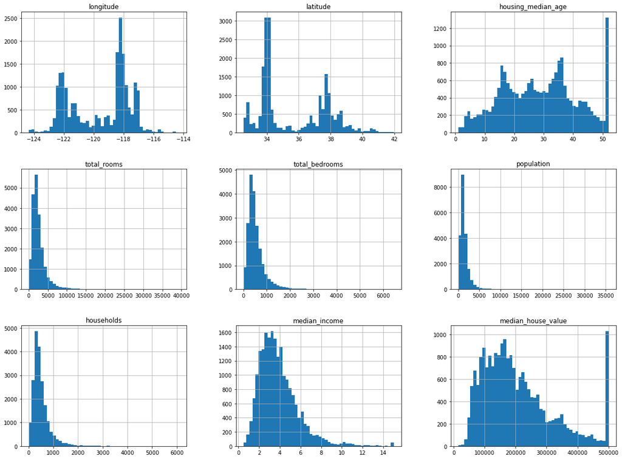

```python
data.hist(bins=50, figsize=(20,15))
plt.show()
```

##### Distribution of the target column

We want to know how well the target is distibuted

```python
data[col_target].head()
```

```
0    452600.0
1    358500.0
2    352100.0
3    341300.0
4    342200.0
Name: median_house_value, dtype: float64
```

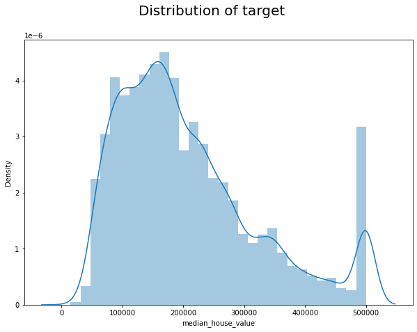

```python
import seaborn as sns

def dist_plot(col):
    plt.figure(figsize=(10,7), facecolor='white')
    sns.distplot(data[col],bins=30,kde=True)
    plt.suptitle("Distribution of target", fontsize=20)
    plt.show()

dist_plot(col_target)
```

### 2.4. Correlation

```python
import seaborn as sns
corr_df = data.corr(method='pearson')
corr_df.style.background_gradient(cmap='coolwarm')
```

|  | longitude | latitude | housing_median_age | total_rooms | total_bedrooms | population | households | median_income | median_house_value |
| --- | --- | --- | --- | --- | --- | --- | --- | --- | --- |
| longitude | 1.00 | -0.92 | -0.11 | 0.04 | 0.07 | 0.10 | 0.06 | -0.02 | -0.05 |
| latitude | -0.92 | 1.00 | 0.01 | -0.04 | -0.07 | -0.11 | -0.07 | -0.08 | -0.14 |
| housing_median_age | -0.11 | 0.01 | 1.00 | -0.36 | -0.32 | -0.30 | -0.30 | -0.12 | 0.11 |
| total_rooms | 0.04 | -0.04 | -0.36 | 1.00 | 0.93 | 0.86 | 0.92 | 0.20 | 0.13 |
| total_bedrooms | 0.07 | -0.07 | -0.32 | 0.93 | 1.00 | 0.88 | 0.98 | -0.01 | 0.05 |
| population | 0.10 | -0.11 | -0.30 | 0.86 | 0.88 | 1.00 | 0.91 | 0.00 | -0.02 |
| households | 0.06 | -0.07 | -0.30 | 0.92 | 0.98 | 0.91 | 1.00 | 0.01 | 0.07 |
| median_income | -0.02 | -0.08 | -0.12 | 0.20 | -0.01 | 0.00 | 0.01 | 1.00 | 0.69 |
| median_house_value | -0.05 | -0.14 | 0.11 | 0.13 | 0.05 | -0.02 | 0.07 | 0.69 | 1.00 |

### 3. Data Preparation

##### 3.1 Mean target encoding

We do apply mean target encoding to transform categorical variables into numerical features that we will use as final predictors in our model.

```python
def mean_target_encoding(dt, predictor, target, alpha = 0.01):
    total_cnt = len(dt)
    total_dr = np.mean(dt[target])
    dt_grp = dt.groupby(predictor).agg(
        categ_dr = (target, np.mean),
        categ_cnt = (target, len)
    )

    dt_grp['categ_freq'] = dt_grp['categ_cnt'] / total_cnt
    dt_grp['categ_encoding'] = (dt_grp['categ_freq'] * dt_grp['categ_dr'] + alpha * total_dr) / (dt_grp['categ_freq'] + alpha)

    return dt_grp[['categ_encoding']].to_dict()['categ_encoding']

# METADEFINITION
#name of the target column
col_target = "median_house_value"
# define the list of possible predictors
cols_pred = list(data.drop(columns = col_target).columns)
# define list of numerical predictors
cols_pred_num = [col for col in cols_pred if data[col].dtype != 'O']
# define list of categorical predictors
cols_pred_cat = [col for col in cols_pred if data[col].dtype == 'O']
```

```python
# Save the mean encoding parameters for the test set
list_of_mean_encoding = []
for pred in cols_pred_cat:
    new_vals = mean_target_encoding(
        dt=data,
        predictor=pred,
        target=col_target
    )
    list_of_mean_encoding.append([pred,new_vals])

# encode categorical predictors
for pred in cols_pred_cat:
    new_vals = mean_target_encoding(
        dt=data,
        predictor=pred,
        target=col_target
    )

    additional_values = set(data[data[pred].notnull()][pred].unique()) - set(new_vals.keys())
    for p in additional_values:
        new_vals[p] = total_dr

    data['MTE_' + pred] = data[pred].replace(new_vals)

    if 'MTE_' + pred not in cols_pred:
        cols_pred.append('MTE_' + pred)

    if pred in cols_pred:
        cols_pred.remove(pred)

# Drop all the old categorical variables
data.drop(columns = cols_pred_cat, inplace = True)
```

```python
final_predictors = list(data.drop(columns = col_target).columns)
```

```python
# find columns with infinity values
cols_with_inf = []
for col in final_predictors:
    if np.any(np.isinf(data[col])):
        cols_with_inf.append(col)
        print(f'Column {col} includes infinity values.')

# replace infinity values
for col in cols_with_inf:
    data[col].replace(np.inf, 9999999, inplace = True)


# find columns with NEGATIVE infinity values
cols_with_neginf = []
for col in final_predictors:
    if np.any(np.isneginf(data[col])):
        cols_with_neginf.append(col)
        print(f'Column {col} includes negative infinity values.')

# replace NEGATIVE infinity values
for col in cols_with_neginf:
    data[col].replace(np.inf, 9999999, inplace = True)

# find columns with NaN values ALL
cols_with_nan = []
for col in final_predictors:
    if np.any(np.isnan(data[col])):
        cols_with_nan.append(col)
        print(f'Column {col} includes NaN values.')


# replace NaN values
for col in cols_with_nan:
    data[col].replace(np.nan, 9999999, inplace = True)
```

```
Column total_bedrooms includes NaN values.
```

```python
print(f'{data.shape[0]} rows and {data.shape[1]} columns')
# Check each column for missing values
print(f'The train set has {data.isna().any().sum()} columns with missing values')
```

```
20640 rows and 10 columns
The train set has 0 columns with missing values
```

##### 3.3. Data Splitting

We know need to split our original dataset into train_set (to train the model) and test_set to evaluate the model and  
the entire orginal data will be used as a validation_set to prove that our model performs well.

```python
# Split the data in train & test
train_set, test_set = train_test_split(data,test_size=0.2,random_state=2)
test_set=test_set.drop(columns=col_target)
train_set.shape, test_set.shape
print(f'The train set has {train_set.shape[0]} rows and {train_set.shape[1]} columns')
# Check each column for missing values
print(f'The train set has {train_set.isna().any().sum()} columns with missing values')
print(f'The test set has {test_set.shape[0]} rows and {test_set.shape[1]} columns')
# Check each column for missing values
print(f'The test set has {test_set.isna().any().sum()} columns with missing values')
```

```
The train set has 16512 rows and 10 columns
The train set has 0 columns with missing values
The test set has 4128 rows and 9 columns
The test set has 0 columns with missing values
```

```python
X=train_set.drop(columns=col_target)
Y=train_set[col_target]
Xtr,Xts,Ytr,Yts = train_test_split(X,Y,test_size=0.2)
# Split the data in train & test
data_train, data_test = train_test_split(data,test_size=0.2,random_state=2)
```

## 4. Modelling

```python
import numpy as np
import pandas as pd
import matplotlib.pyplot as plt
import seaborn as sns
import datetime
from tqdm.notebook import tqdm
from sklearn.metrics import roc_auc_score, roc_curve
from sklearn.model_selection import RandomizedSearchCV
from sklearn.model_selection import StratifiedKFold
import xgboost as xgb
```

```python
from sklearn.tree import DecisionTreeClassifier
from sklearn.experimental import enable_halving_search_cv
from sklearn.model_selection import HalvingRandomSearchCV
from scipy.stats import expon
from xgboost import XGBRegressor
from sklearn.metrics import mean_absolute_error
from sklearn.metrics import r2_score
RANDOM_STATE = 12
```

We build the model we some initial parameters that we will decide to fine tune later.

For this modelling task we are predicting continuous variable synonym to a regression task. There are several models(Linera regression, Random forest, decision Tree regrerssor,...) we could use but we decide to XGBoostRegressor.  
The two main reasons to use XGBoost are execution speed and model performance. XGBoost dominates structured or tabular datasets on classification and regression predictive modeling problems.

LINEAR REGRESSION

```python
# suggestion: try first a linear regression model

from sklearn.linear_model import LinearRegression

LR=LinearRegression().fit(Xtr,Ytr)

print("Intercept:", LR.intercept_)
print("coef_B:", LR.coef_)
```

```
Intercept: -2198468.1876074853
coef_B: [-2.56093409e+04 -2.54085645e+04  9.12124733e+02 -9.69783616e-02
  2.88759493e-04 -4.55702467e+01  1.43035174e+02  3.75186086e+04
  3.45472049e-01]
```

```python
from sklearn.model_selection import cross_val_score
# scoring itself directly (not recommended, overrates performance)
print('R2 on itself: ', LR.score(Xtr, Ytr))
# scoring by a cross-validation
scores = cross_val_score(LR, Xtr, Ytr, cv=4)
print('R2 by cval: ', scores)
```

```
R2 on itself:  0.6443468094052092
R2 by cval:  [0.64372936 0.65881847 0.63783127 0.6321733 ]
```

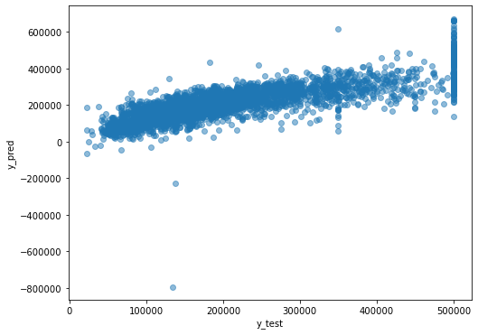

```python
Ypred=LR.predict(Xts)
lin_r = r2_score(Yts, Ypred)
# plotting actual vs prediction
plt.scatter(Yts, Ypred, alpha = 0.5)
plt.xlabel("y_test")
plt.ylabel("y_pred")
plt.show()
```

TREE DECISION REGRESSOR

```python
# use non-linear model DecisionTreeRegressor
from sklearn.tree import DecisionTreeRegressor

DTR = DecisionTreeRegressor(max_depth=25, random_state=42)
DTR.fit(Xtr, Ytr)

from sklearn.model_selection import cross_val_score
# scoring itself directly (not recommended, overrates performance)
print('R2 on itself: ', DTR.score(Xtr, Ytr))
# scoring by a cross-validation
scores = cross_val_score(DTR, Xtr, Ytr, cv=4)
print('R2 by cval: ', scores)
```

```
R2 on itself:  0.9997096786463471
R2 by cval:  [0.62727021 0.62499638 0.63317327 0.60994513]
```

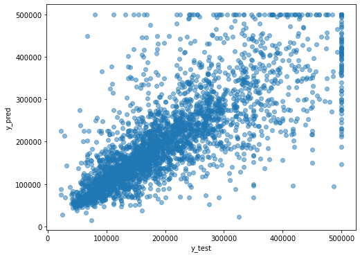

```python
Ypred=DTR.predict(Xts)
DT = r2_score(Yts, Ypred)
# plotting actual vs prediction
plt.scatter(Yts, Ypred, alpha = 0.5)
plt.xlabel("y_test")
plt.ylabel("y_pred")
plt.show()
```

XGBOOST REGRESSOR

```python
model = XGBRegressor(n_estimators=100,
                    learning_rate = .1,
                    max_depth = 6,
                    random_state=42,
                    n_jobs = -1,
                    early_stopping_rounds=10)
```

Now let's train our model with the train_set and predict on test_set

[output not shown]

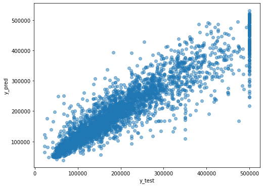

```python
model.fit(Xtr,Ytr)
Ypred=model.predict(Xts)
lin_r = r2_score(Yts, Ypred)
# plotting actual vs prediction
plt.scatter(Yts, Ypred, alpha = 0.5)
plt.xlabel("y_test")
plt.ylabel("y_pred")
plt.show()
```

```python
predictions = model.predict(test_set)
predictions
```

```
array([286810.78, 165728.36, 103378.59, ..., 149906.23,  93177.09,
       237239.56], dtype=float32)
```

```python
r2 = r2_score(Yts, Ypred)
r2
```

```
0.8326313899835323
```

##### 4.1 Feature importance

Now let's explore the feature importance on the model performance.

[figure not shown]

```python
from xgboost import plot_importance
figsize=(10,10)
fig, ax = plt.subplots(1,1,figsize=figsize)
plot_importance(model, ax=ax,height = 10)
```

#### 4.2 Hyperparameters research

We use so called fine tuning to find the best parameters for our model. We decide to use HalvingRandomSearchCV.

```python
from sklearn.experimental import enable_halving_search_cv
from sklearn.model_selection import HalvingRandomSearchCV
from scipy.stats import expon
import warnings
warnings.filterwarnings("ignore")
```

```python
params_dist = [
    {
        'max_depth': [2, 3, 5, 8, 16],
        'criterion': ['gini', 'entropy'],
        'min_samples_split': np.unique(np.logspace(1, 4, num=30, dtype=np.int)),
        'ccp_alpha': expon(scale=0.00025),
        "learning_rate" : [0.05,0.10,0.15],
        "gamma": [ 0.0, 0.1, 0.2 ]
    }
]

tree = XGBRegressor(randon_state=RANDOM_STATE)

clf = HalvingRandomSearchCV(
    estimator=tree,
    param_distributions=params_dist,
    n_candidates=50,
    factor=2,
    resource='n_samples',
    min_resources='exhaust',
    cv=3,
    scoring='r2',
    error_score=0,
    refit=True,
    random_state=RANDOM_STATE
)

clf.fit(Xtr, Ytr)
```

[output not shown]

[output cut: 2375 more lines]

[output not shown]

```
HalvingRandomSearchCV(cv=3, error_score=0,
                      estimator=XGBRegressor(base_score=None, booster=None,
                                             colsample_bylevel=None,
                                             colsample_bynode=None,
                                             colsample_bytree=None,
                                             enable_categorical=False,
                                             gamma=None, gpu_id=None,
                                             importance_type=None,
                                             interaction_constraints=None,
                                             learning_rate=None,
                                             max_delta_step=None,
                                             max_depth=None,
                                             min_child_weight=None, missing=nan,
                                             mono...
                      param_distributions=[{'ccp_alpha': <scipy.stats._distn_infrastructure.rv_frozen object at 0x7f91ce0ad3a0>,
                                            'criterion': ['gini', 'entropy'],
                                            'gamma': [0.0, 0.1, 0.2],
                                            'learning_rate': [0.05, 0.1, 0.15],
                                            'max_depth': [2, 3, 5, 8, 16],
                                            'min_samples_split': array([   10,    12,    16,    20,    25,    32,    41,    52,    67,
          85,   108,   137,   174,   221,   280,   356,   452,   573,
         727,   923,  1172,  1487,  1887,  2395,  3039,  3856,  4893,
        6210,  7880, 10000])}],
                      random_state=12,
                      refit=<function _refit_callable at 0x7f91cc79b700>,
                      scoring='r2')
```

The hyperparameters reseacrh show that the best parameters for our modelling are following:

```python
clf.best_params_
```

```
{'ccp_alpha': 0.00018413166651240812,
 'criterion': 'gini',
 'gamma': 0.0,
 'learning_rate': 0.15,
 'max_depth': 5,
 'min_samples_split': 452}
```

```python
pd.DataFrame(clf.cv_results_).head()
```

|  | iter | n_resources | mean_fit_time | std_fit_time | mean_score_time | std_score_time | param_ccp_alpha | param_criterion | param_gamma | param_learning_rate | param_max_depth | param_min_samples_split | params | split0_test_score | split1_test_score | split2_test_score | mean_test_score | std_test_score | rank_test_score | split0_train_score | split1_train_score | split2_train_score | mean_train_score | std_train_score |
| --- | --- | --- | --- | --- | --- | --- | --- | --- | --- | --- | --- | --- | --- | --- | --- | --- | --- | --- | --- | --- | --- | --- | --- | --- |
| 0 | 0 | 412 | 0.09 | 2.72e-02 | 2.89e-03 | 1.40e-04 | 0.0 | gini | 0.1 | 0.1 | 5 | 20 | {'ccp_alpha': 4.185710574647497e-05, 'criterio... | 0.56 | 0.77 | 0.61 | 0.64 | 0.09 | 63 | 0.99 | 0.99 | 0.99 | 0.99 | 2.94e-04 |
| 1 | 0 | 412 | 0.24 | 1.03e-02 | 3.21e-03 | 5.52e-05 | 0.0 | gini | 0.2 | 0.1 | 16 | 32 | {'ccp_alpha': 0.00032147817783043163, 'criteri... | 0.52 | 0.72 | 0.58 | 0.61 | 0.08 | 86 | 1.00 | 1.00 | 1.00 | 1.00 | 1.20e-06 |
| 2 | 0 | 412 | 0.04 | 4.48e-03 | 2.60e-03 | 5.91e-05 | 0.0 | gini | 0.2 | 0.15 | 2 | 1487 | {'ccp_alpha': 8.498171963927468e-06, 'criterio... | 0.51 | 0.77 | 0.61 | 0.63 | 0.11 | 70 | 0.90 | 0.91 | 0.89 | 0.90 | 8.89e-03 |
| 3 | 0 | 412 | 0.14 | 4.74e-03 | 2.92e-03 | 2.52e-05 | 0.0 | entropy | 0.2 | 0.1 | 8 | 25 | {'ccp_alpha': 0.00023290387994727609, 'criteri... | 0.55 | 0.74 | 0.58 | 0.62 | 0.08 | 82 | 1.00 | 1.00 | 1.00 | 1.00 | 2.11e-05 |
| 4 | 0 | 412 | 0.07 | 1.13e-03 | 2.83e-03 | 1.02e-04 | 0.0 | gini | 0.0 | 0.15 | 5 | 452 | {'ccp_alpha': 0.00018413166651240812, 'criteri... | 0.55 | 0.77 | 0.62 | 0.65 | 0.09 | 59 | 1.00 | 1.00 | 1.00 | 1.00 | 1.51e-04 |

```python
cvres = pd.DataFrame(clf.cv_results_)

cvres.groupby('iter')['iter'].count()
```

```
iter
0    50
1    25
2    13
3     7
4     4
5     2
Name: iter, dtype: int64
```

Let's plot the results from the hyperparameters research and the r2_score at each iteration.

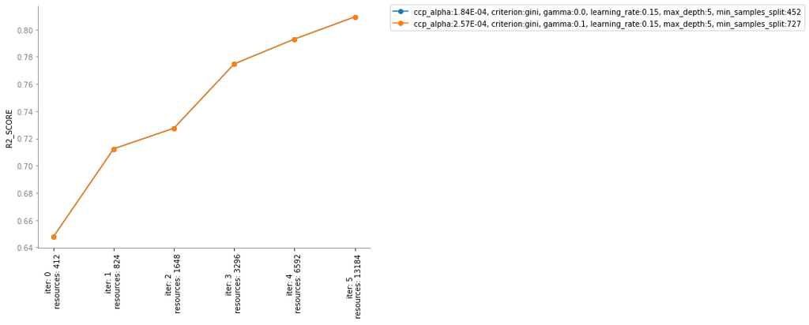

```python
cvres = pd.DataFrame(clf.cv_results_)
param_combs = cvres[cvres['iter'] == 5]['params'].to_list()

cvres_res = pd.DataFrame()
ax = plt.subplot(1,1,1)
for pc in param_combs:
    dt = cvres[cvres['params'] == pc]
    label = ', '.join([f'{p}:{v:.2E}' if p=='ccp_alpha' else f'{p}:{v}' for p,v in pc.items()])
    ax.plot(dt['iter'], dt['mean_test_score'], marker='o', label=label)

ax.set_xticks(dt['iter'])
ax.set_xticklabels(
    cvres[['iter', 'n_resources']].drop_duplicates().apply(lambda row: f'iter: {row[0]}\n resources: {row[1]}', axis = 1).to_list(),
    rotation=90
)

ax.legend(bbox_to_anchor=(1.05, 1.02))
ax.set_ylabel('R2_SCORE')
ax.tick_params(axis='y', colors='gray')
ax.spines['top'].set_visible(False)
ax.spines['right'].set_visible(False)
ax.spines['left'].set_color('gray')
ax.spines['bottom'].set_color('gray')
plt.show()
```

```python
xgb_model_tuned=clf
xgb_model_tuned.best_params_
```

```
{'ccp_alpha': 0.00018413166651240812,
 'criterion': 'gini',
 'gamma': 0.0,
 'learning_rate': 0.15,
 'max_depth': 5,
 'min_samples_split': 452}
```

#### 4.3 Final Model

After finetuning we build our final model using finetuned parameters.

```python
from sklearn import metrics
#Validation data
val_data=data.drop(columns=col_target)
final_target=data[col_target]
predictions=xgb_model_tuned.predict(val_data)
r2 = metrics.r2_score(final_target, predictions)
r2
```

```
0.8600004335098781
```

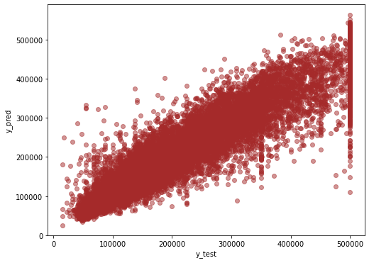

```python
lin_r = metrics.r2_score(final_target, predictions)
# plotting actual vs prediction
plt.scatter(final_target, predictions, color="brown", alpha = 0.5)
plt.xlabel("y_test")
plt.ylabel("y_pred")
plt.show()
```

Author: Doudou BA  
E-mail: presidou@gmail.com